# Assignment5

Ashani Jayasekera

2024-11-13

## Assignment 5

The link to the GitHub repository is: https://github.com/ashanijay/SURV727. The assignment is Assignment5.rmd.

```r
cs_key <- "65c0979cfd3f4f5585b3572df63418505d19b6e7"
```

## Exploring ACS Data

```r
acs_il_c <- getCensus(name = "acs/acs5",
 vintage = 2016,
 vars = c("NAME", "B01003_001E", "B19013_001E", "B19301_001E"),
 region = "county:*",
 regionin = "state:17",
 key = cs_key) %>%
 rename(pop = B01003_001E,
 hh_income = B19013_001E,
 income = B19301_001E)

head(acs_il_c)
```

```
##   state county                       NAME    pop hh_income income
## 1    17    067   Hancock County, Illinois  18633     50077  25647
## 2    17    063    Grundy County, Illinois  50338     67162  30232
## 3    17    091  Kankakee County, Illinois 111493     54697  25111
## 4    17    043    DuPage County, Illinois 930514     81521  40547
## 5    17    003 Alexander County, Illinois   7051     29071  16067
## 6    17    129    Menard County, Illinois  12576     60420  31323
```

Pull the map data for Illinois into a data frame.

```r
il_map <- map_data("county", region = "illinois")
head(il_map)
```

```
##        long      lat group order   region subregion
## 1 -91.49563 40.21018     1     1 illinois     adams
## 2 -90.91121 40.19299     1     2 illinois     adams
## 3 -90.91121 40.19299     1     3 illinois     adams
## 4 -90.91121 40.10704     1     4 illinois     adams
## 5 -90.91121 39.83775     1     5 illinois     adams
## 6 -90.91694 39.75754     1     6 illinois     adams
```

Join the ACS data with the map data. Call the joined data acs_map.

```r
acs_il_c$subregion <-tolower(sapply(strsplit(acs_il_c$NAME, " County,"), function(x) x[1]))
acs_map <- left_join(acs_il_c, il_map, by = "subregion")
```

Plot a mpa of Illinois with counties colored per capita income.

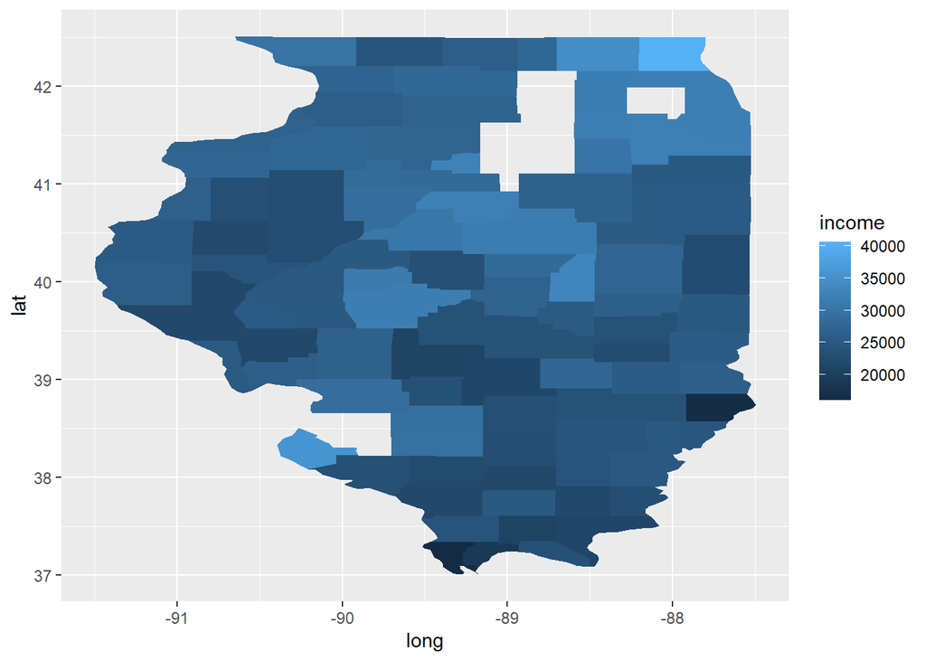

```r
ggplot(acs_map) +
 geom_polygon(aes(x = long, y = lat, group = group, fill = income))
```

## Hierarchial Clustering

Clean the data and then create distance matrix of the cleaned data. We want to find clusters of ounties that are similar in their population, average household income and per capita income.

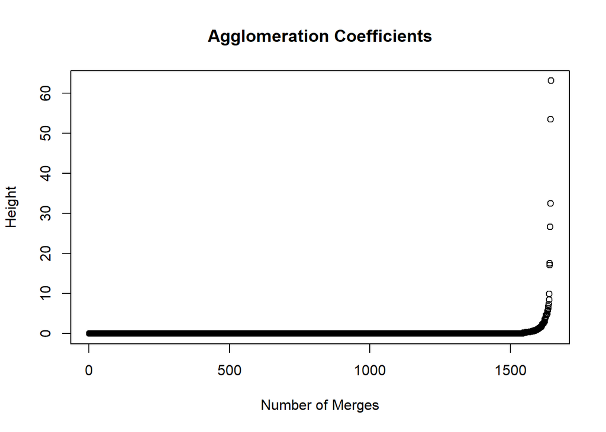

```r
acs_map_clean <- acs_map %>%
  select(pop, hh_income, income) %>%
  mutate_all(scale)
acs_d <- dist(acs_map_clean)
acs_ward <- hclust(acs_d, method = "ward.D2")
plot(acs_ward$height, main = "Agglomeration Coefficients", xlab = "Number of Merges", ylab = "Height")
```

Plot the dendrogram to find a reasonable number of clusters. Draw boxes around the clusters of your cluster solution.

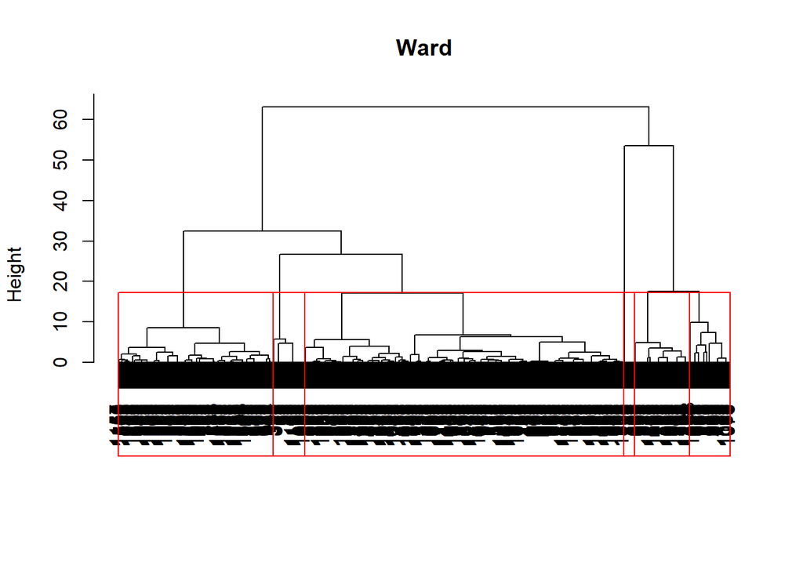

```r
plot(acs_ward, main = "Ward", xlab = "", sub = "")

rect.hclust(acs_ward,
            k = 6,
            border = "red")
```

```r
##need to find the way to get the optimal number of groups
cutree(acs_ward, 6)
```

```
##    [1] 1 1 1 1 1 1 1 1 1 1 1 1 1 1 1 1 1 1 1 1 1 2 2 2 2 2 2 3 3 3 3 3 3 3 3 3 3
##   [38] 4 5 5 5 5 5 5 5 5 5 5 5 5 5 5 5 5 5 5 5 5 5 5 5 5 5 5 5 5 5 5 5 5 5 5 5 5
##   [75] 5 5 5 5 2 2 2 2 2 2 2 2 2 2 2 2 2 2 2 2 2 2 2 2 2 2 2 2 3 6 6 6 6 6 6 6 6
##  [112] 6 6 6 6 6 6 6 6 6 6 6 6 6 6 6 6 6 6 6 6 1 1 1 1 1 1 1 1 1 1 1 1 1 1 1 1 1
##  [149] 1 1 1 1 1 1 1 1 1 1 1 1 1 1 1 1 1 1 1 1 1 1 1 1 1 1 1 4 4 4 4 4 4 4 4 4 4
##  [186] 4 4 4 4 4 4 4 4 4 4 4 4 1 1 1 1 1 1 1 1 1 1 1 1 1 1 1 1 1 1 1 1 1 1 4 4 4
##  [223] 4 4 4 4 4 3 3 3 3 3 3 3 3 3 3 3 3 3 3 3 3 3 3 3 3 1 1 1 1 1 1 1 1 1 1 1 1
##  [260] 1 1 1 1 1 1 1 1 1 1 1 1 1 1 1 1 1 1 1 1 1 1 1 3 1 1 1 1 1 1 1 1 1 1 1 1 1
##  [297] 1 1 1 1 1 1 1 1 3 3 3 3 3 3 3 3 3 3 3 3 3 3 3 3 3 3 3 3 3 3 3 3 3 3 3 3 3
##  [334] 3 3 3 3 3 3 3 3 3 3 3 3 3 3 3 3 3 1 1 1 1 1 1 1 1 1 1 1 1 1 1 1 3 3 3 3 3
##  [371] 3 3 3 3 3 3 3 3 3 4 4 4 4 4 4 5 5 5 5 5 5 5 5 5 5 5 5 1 1 1 1 1 1 1 1 1 1
##  [408] 1 1 1 1 1 1 1 1 1 1 1 1 1 1 1 1 1 1 1 1 1 1 1 1 1 1 1 1 1 1 1 1 1 1 1 1 1
##  [445] 1 1 1 1 1 1 1 1 1 1 1 1 1 1 1 1 1 1 1 1 1 1 1 1 1 1 1 1 1 1 1 1 1 1 1 1 1
##  [482] 1 1 1 1 1 1 1 1 1 1 1 1 1 1 1 1 1 4 4 4 4 4 4 4 4 4 4 4 4 4 4 4 4 4 4 4 4
##  [519] 4 4 4 3 3 3 3 3 3 3 3 3 3 3 3 3 3 3 3 3 3 3 3 3 3 3 3 3 3 3 3 3 3 3 3 3 3
```

[output cut: 30 more lines]

Visualize the county clusters on a map. Foe this task, create a new acs_map object that now includes cluster membership as a new column. This column should be called cluster.

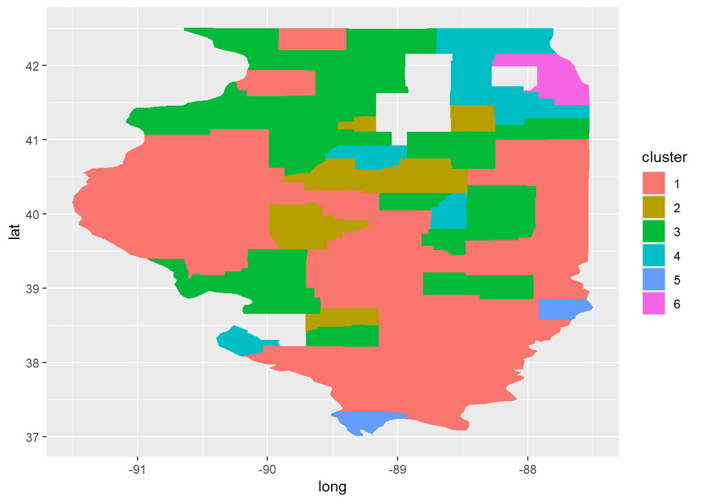

```r
acs_map$cluster <- as.factor(cutree(acs_ward, 6))

ggplot(acs_map) +
  geom_polygon(aes(x = long, y = lat, group = group, fill = cluster))
```

## Census Tracts

```r
acs_il_t <- getCensus(
  name = "acs/acs5",
  vintage = 2016,
  vars = c("NAME", "B01003_001E", "B19013_001E", "B19301_001E"),
  region = "tract:*",
  regionin = "state:17",  # Illinois (state FIPS = 17)
  key = cs_key
) %>%
  # Replace -666666666 with NA in all columns
  mutate(across(everything(), ~ ifelse(. == -666666666, NA, .))) %>%
  # Rename columns
  rename(
    pop = B01003_001E,
    hh_income = B19013_001E,
    income = B19301_001E
  )
acs_il_t <- acs_il_t[complete.cases(acs_il_t), ]
head(acs_il_t)
```

```
##   state county  tract                                        NAME  pop
## 1    17    031 806002 Census Tract 8060.02, Cook County, Illinois 7304
## 2    17    031 806003 Census Tract 8060.03, Cook County, Illinois 7577
## 3    17    031 806400    Census Tract 8064, Cook County, Illinois 2684
## 4    17    031 806501 Census Tract 8065.01, Cook County, Illinois 2590
## 5    17    031 750600    Census Tract 7506, Cook County, Illinois 3594
## 6    17    031 310200    Census Tract 3102, Cook County, Illinois 1521
##   hh_income income
## 1     56975  23750
## 2     53769  25016
## 3     62750  30154
## 4     53583  20282
## 5     40125  18347
## 6     63250  31403
```

## k-Means

Clean the data for clustering census tracts pased on population, average hourshold income, and per capita income.

Since we want to use K Means in this section, we start by determining the optimal number of K that results in Clusters with low within but high between variation. Plot within cluster sums of squares for a range of K (e.g. up to 20).

Run kmeans() for the optimal number of clusters based on the plot above.

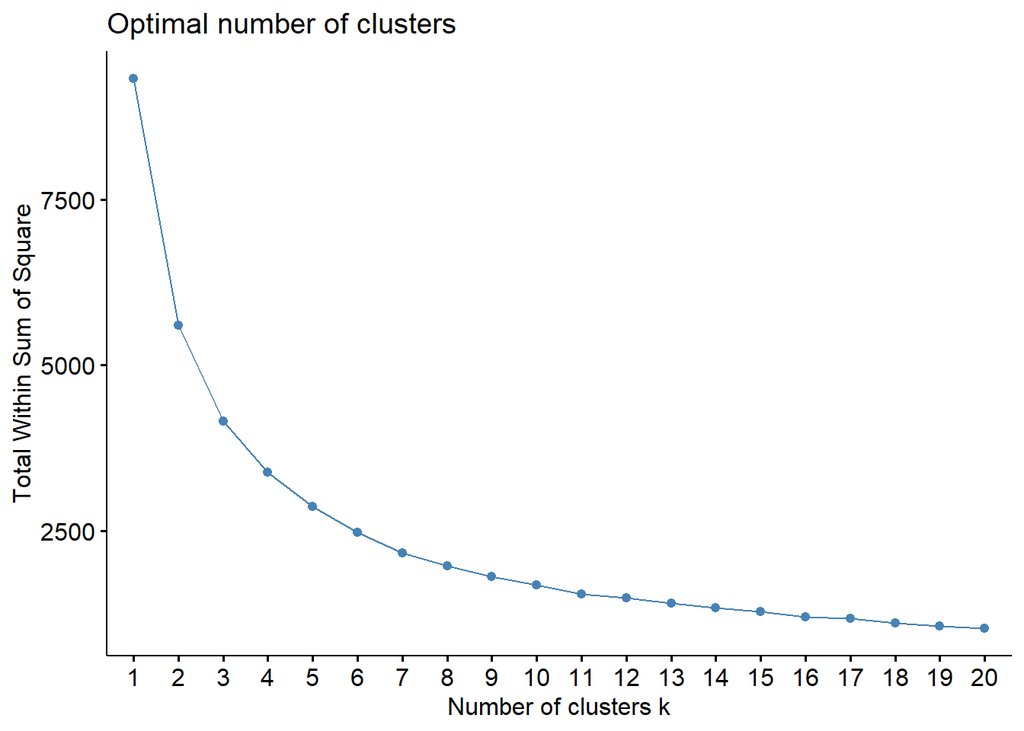

```r
acs_il_clean <- acs_il_t %>%
  select(pop, hh_income, income) %>%
  mutate_all(scale)
acs_il_clean <- acs_il_clean[complete.cases(acs_il_clean), ]


fviz_nbclust(acs_il_clean, #data set we want to use
             kmeans, #cluster method
             method = "wss", #method used for estimating the optimal number of clusters
             k.max = 20)
```

Based on the plots, the optimal number of clusters is either 2, 3, or 6. It is not clear. But the best I think is 6. The cluster means for population, household income, adn per capita income grouped by cluster is below.

```r
km_1 <- kmeans(acs_il_clean, 6, nstart = 20)
km_1
```

```
## K-means clustering with 6 clusters of sizes 153, 857, 152, 509, 706, 732
##
## Cluster means:
##           pop  hh_income      income
## 1  2.50208293  0.8677948  0.46768633
## 2 -0.45475134 -0.1039387 -0.07556527
## 3 -0.14811732  2.5193978  2.93950053
## 4  0.07929597  1.0386480  0.90473730
## 5  0.78092031 -0.3295962 -0.41249620
## 6 -0.76813435 -0.9871892 -0.85094211
##
## Clustering vector:
##    1    2    3    4    5    6    7    8    9   10   11   12   13   14   15   16
##    5    5    2    2    6    2    6    2    6    6    5    2    3    3    3    3
##   17   18   19   20   21   22   23   24   25   26   27   28   29   30   31   32
```

[output cut: 396 more lines]

In addition, display the most frequent county that can be observed within each cluster.

```r
acs_il_t$cluster <- km_1$cluster
result <- acs_il_t %>%
  group_by(cluster, county) %>%
  count() %>%
  group_by(cluster) %>%
filter(n == max(n)) %>%
  ungroup()

 print(result)
```

```
## # A tibble: 6 × 3
##   cluster county     n
##     <int> <chr>  <int>
## 1       1 031       42
## 2       2 031      260
## 3       3 031       95
## 4       4 031      216
## 5       5 031      336
## 6       6 031      363
```

To automate K Means clustering, program a function based on kmeans() that takes K as an argument.

```r
kmeans_cluster <- function(K, dataset.clean, dataset.full){
    cluster_id <- kmeans(dataset.clean, K, nstart = 20)$cluster
  name <- paste0("clusterID_", K)
  dataset.full <- cbind(dataset.full, cluster_id)
  names(dataset.full)[dim(dataset.full)[2]] <- name
  return(dataset.full)
  }

for(k in 2:10){
  acs_il_t <- kmeans_cluster(K = k, dataset.clean = acs_il_clean, dataset.full = acs_il_t)
}
head(acs_il_t)
```

```
##   state county  tract                                        NAME  pop
## 1    17    031 806002 Census Tract 8060.02, Cook County, Illinois 7304
## 2    17    031 806003 Census Tract 8060.03, Cook County, Illinois 7577
## 3    17    031 806400    Census Tract 8064, Cook County, Illinois 2684
## 4    17    031 806501 Census Tract 8065.01, Cook County, Illinois 2590
## 5    17    031 750600    Census Tract 7506, Cook County, Illinois 3594
## 6    17    031 310200    Census Tract 3102, Cook County, Illinois 1521
##   hh_income income cluster clusterID_2 clusterID_3 clusterID_4 clusterID_5
## 1     56975  23750       5           1           1           4           3
## 2     53769  25016       5           1           1           4           3
## 3     62750  30154       2           1           2           2           5
## 4     53583  20282       2           1           2           1           4
## 5     40125  18347       6           1           2           1           4
## 6     63250  31403       2           1           2           2           5
##   clusterID_6 clusterID_7 clusterID_8 clusterID_9 clusterID_10
## 1           1           2           8           5            1
## 2           1           2           8           5            1
## 3           4           1           7           4            6
## 4           4           7           7           4            6
## 5           5           7           5           3            4
## 6           4           1           7           4            6
```